# ARIMA

### 1、加载数据

```r
skirts <- scan("http://robjhyndman.com/tsdldata/roberts/skirts.dat", skip=5)
```

```r
str(skirts)
```

```
##  num [1:46] 608 617 625 636 657 691 728 784 816 876 ...
```

```r
head(skirts)
```

```
## [1] 608 617 625 636 657 691
```

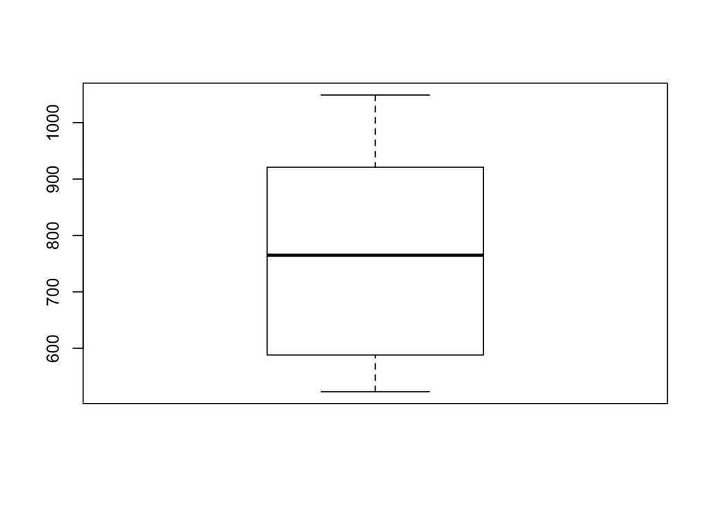

```r
boxplot(skirts)
```

```r
length(skirts)
```

```
## [1] 46
```

### 2、把数据转化为是时间序列

```r
skirts_ts <- ts(skirts, start=c(1886), frequency=1)
```

**1)查看时间序列对应的时间**

```r
skirts_ts
```

```
## Time Series:
## Start = 1886
## End = 1931
## Frequency = 1
##  [1]  608  617  625  636  657  691  728  784  816  876  949  997 1027 1047
## [15] 1049 1018 1021 1012 1018  991  962  921  871  829  822  820  802  821
## [29]  819  791  746  726  661  620  588  568  542  551  541  557  556  534
## [43]  528  529  523  531
```

**2)画出时间序列图**

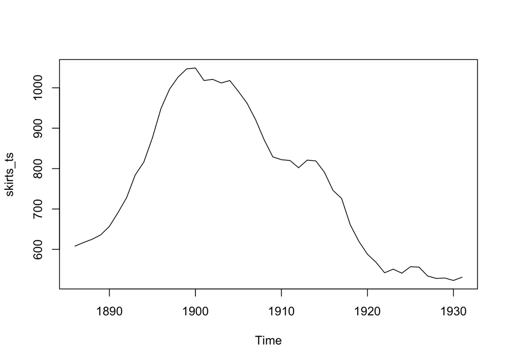

```r
plot.ts(skirts_ts)
```

### 3、做差分得到平稳序列

**1)做时间序列的一阶差分**

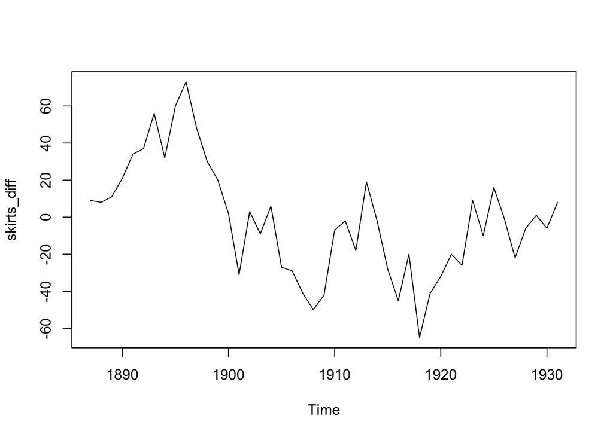

```r
skirts_diff <- diff(skirts_ts, differences = 1)
plot.ts(skirts_diff)
```

*从一阶差分的图中可以看出，数据仍是不平稳的，继续差分*

**2)做时间序列的二阶差分**

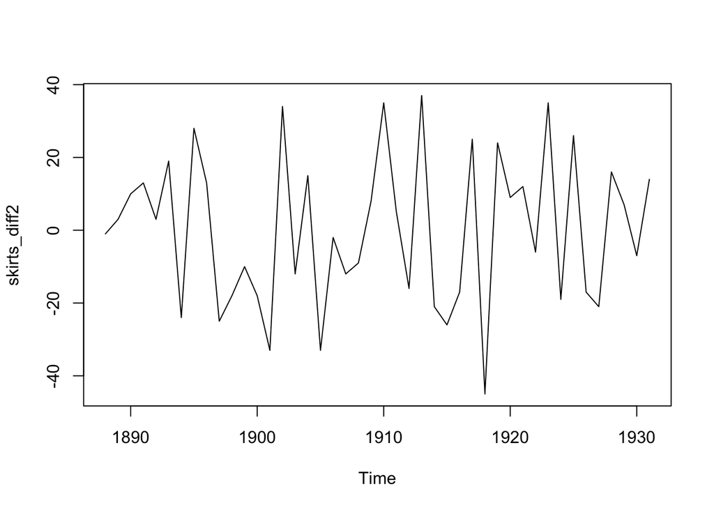

```r
skirts_diff2 <- diff(skirts_ts, differences = 2)
plot.ts(skirts_diff2)
```

*二次差分后的时间序列在均值和方差上看起来是平稳了*

### 4、找到合适的ARIMA模型

*寻找 ARIMA(p,d,q)中合适的 p 值和 q*

**1)自相关图ACF**

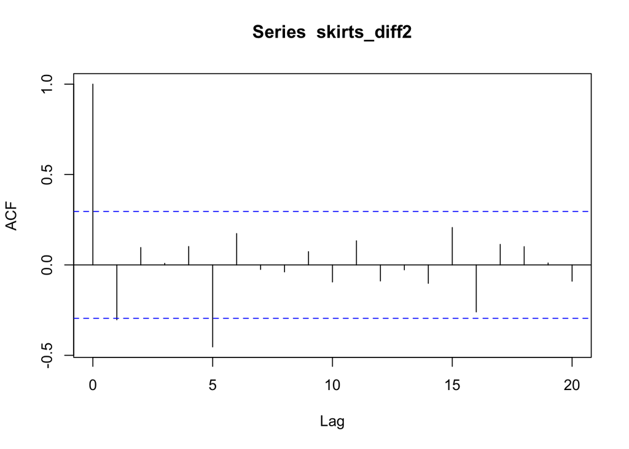

```r
acf(skirts_diff2, lag.max = 20)
```

```r
acf(skirts_diff2, lag.max = 20, plot = F)
```

```
##
## Autocorrelations of series 'skirts_diff2', by lag
##
##      0      1      2      3      4      5      6      7      8      9
##  1.000 -0.303  0.096  0.009  0.102 -0.453  0.173 -0.025 -0.039  0.073
##     10     11     12     13     14     15     16     17     18     19
## -0.094  0.133 -0.089 -0.027 -0.102  0.207 -0.260  0.114  0.101  0.011
##     20
## -0.090
```

*自相关图显示滞后1阶自相关值基本没有超过边界值，虽然5阶自相关值超出边界，那么很可能属于偶然出现的，而自相关值在其他上都没有超出显著边界， 而且我们可以期望 1 到 20 之间的会偶尔超出 95%的置信边界。 自相关图5阶后结尾*

**2)偏相关图PACF**

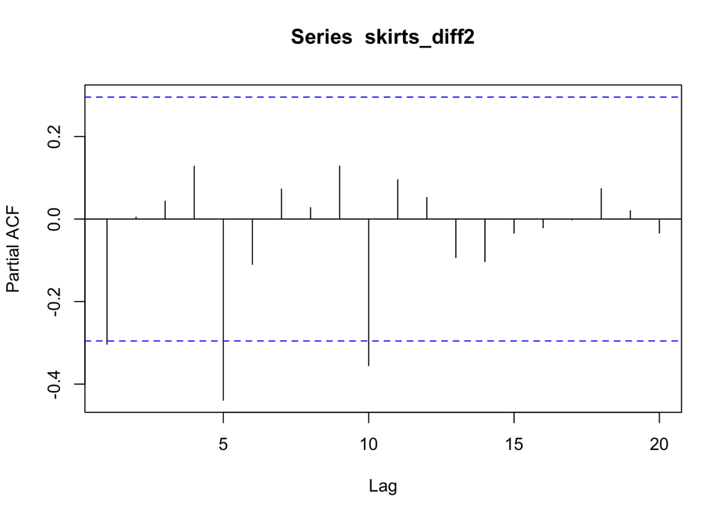

```r
pacf(skirts_diff2, lag.max = 20)
```

```r
pacf(skirts_diff2, lag.max = 20, plot = F)
```

```
##
## Partial autocorrelations of series 'skirts_diff2', by lag
##
##      1      2      3      4      5      6      7      8      9     10
## -0.303  0.005  0.043  0.128 -0.439 -0.110  0.073  0.028  0.128 -0.355
##     11     12     13     14     15     16     17     18     19     20
##  0.095  0.052 -0.094 -0.103 -0.034 -0.021 -0.002  0.074  0.020 -0.034
```

*偏自相关值选1阶后结尾* *故我们的ARMIA模型为armia（1,2,5*

**3)使用auto.arima()函数，自动获取最佳的ARIMA模型**

```r
library(forecast)
auto.arima(skirts_ts, ic=c("aicc", "aic", "bic"), trace = T)
```

```
##
##  ARIMA(2,2,2)                    : Inf
##  ARIMA(0,2,0)                    : 393.6216
##  ARIMA(1,2,0)                    : 391.6212
##  ARIMA(0,2,1)                    : 392.0664
##  ARIMA(2,2,0)                    : 393.9273
##  ARIMA(1,2,1)                    : 393.9276
##  ARIMA(2,2,1)                    : Inf
##
##  Best model: ARIMA(1,2,0)
```

```
## Series: skirts_ts
## ARIMA(1,2,0)
##
## Coefficients:
##           ar1
##       -0.2997
## s.e.   0.1424
##
## sigma^2 estimated as 397.8:  log likelihood=-193.66
## AIC=391.33   AICc=391.62   BIC=394.9
```

*Best model: ARIMA(1,2,0)*

### 5、建立ARIMA模型：并对比arima(1, 2, 0)与arima(1, 2, 5)模型

**1）arima(1, 2, 0)模型**

```r
(skirts_arima <- arima(skirts_ts, order = c(1, 2, 0)))
```

```
##
## Call:
## arima(x = skirts_ts, order = c(1, 2, 0))
##
## Coefficients:
##           ar1
##       -0.2997
## s.e.   0.1424
##
## sigma^2 estimated as 388.7:  log likelihood = -193.66,  aic = 391.33
```

*aic = 391.33*

**2）arima(1, 2, 5)模型**

```r
(skirts_arima <- arima(skirts_ts, order = c(1, 2, 5)))
```

```
##
## Call:
## arima(x = skirts_ts, order = c(1, 2, 5))
##
## Coefficients:
##           ar1     ma1     ma2     ma3     ma4      ma5
##       -0.4345  0.2762  0.1033  0.1472  0.0267  -0.8384
## s.e.   0.1837  0.2171  0.2198  0.2716  0.1904   0.2888
##
## sigma^2 estimated as 206.1:  log likelihood = -183.8,  aic = 381.6
```

*aic = 381.6*

*AIC是赤池消息准则SC是施瓦茨准则，当两个数值最小时，则是最优滞后分布的长度。我们进行模型选择时，AIC值越小越好。所以arima(1, 2, 5)模型较好*

### 6、预测：预测5年后裙子的边缘直径

```r
(skirts_forecast <- forecast.Arima(skirts_arima, h=5, level = c(99.5)))
```

```
##      Point Forecast  Lo 99.5  Hi 99.5
## 1932       548.5762 507.1167 590.0357
## 1933       545.1793 459.3292 631.0295
## 1934       540.9354 396.3768 685.4940
## 1935       531.8838 316.2784 747.4892
## 1936       529.1296 233.2625 824.9968
```

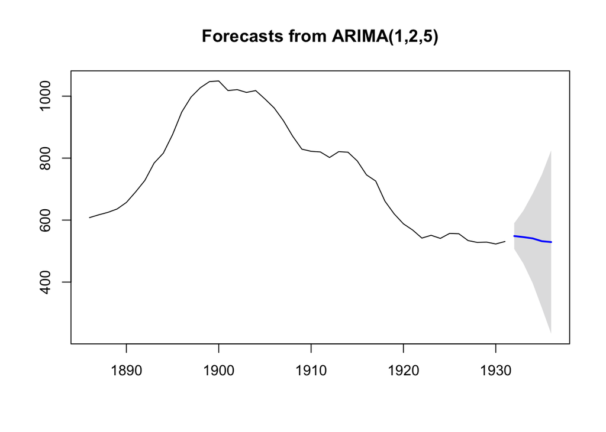

```r
plot.forecast(skirts_forecast)
```

### 7、检验

*观察 ARIMA 模型的预测误差是否是平均值为 0 且方差为常数的正态分布，同时也要观察连续预测误差是否自相关*

**1）检验预测误差的自相关性**

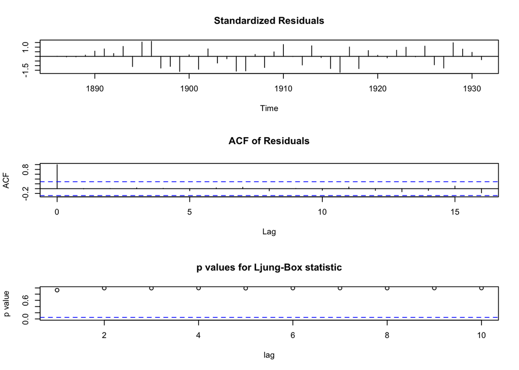

```r
tsdiag(skirts_arima)
```

第一个图表代表估计模型误差的绘图。英文叫做Standardized Residuals, 上面有很多竖线在横向坐标的上下分布。如果这个估计的模型比较可信，竖线的长度是比较相似的。如果竖线的长度互相有很大出入或者根本就不同，估计模型的可信度就非常差。下面误差绘图中竖线的长度比较相似，都处在稳定范围之内，即估计的模型没产生不符合要求的误差分布。

再介绍输出的第二张绘图，标题是ACF of Residuals。ACF指数据点相互之间的关系，当然在生成这个数据时，数据点之间互相独立，并不存在任何关系。所以在这张图上，只有位于0刻度上的竖线最高，其ACF值为1。 这个0代表数据点与自己相比较， 即数据点永远和它自己有关系，这种关系数值为1。其他横向数轴上的刻度代表一个数据点于其他数据点之间的关系，这些刻度上竖线的长度几乎等于0，即这个数据点与其他数据点没明显关系。这张ACF图代表估计的模型没造成误差之间的任何关系。这是符合数据生成时每个数据都是独立的这个前提的。由此可见，这ACF图符合检测要求。

下面来介绍第三张图，也就是Ljung-Box 指标。这个指标可对每一个时间序列的延迟进行显著性的评估。这张图的横坐标代表时间序列的延迟，纵坐标代表P-value，即显著性。如果P-value十分小，就说明在其相对应的延迟点上是显著的。我们就需要抛弃所假设的模型，并且结论在所假设的模型不可信。需要注意的是，他们使用假设的模型对一个时间序列进行估计，如果P-value是显著的话，我们使用的模型就不可信，需要尝试其他新模型。具体判定技巧是，P-value点的高度越高，我们的模型越可信。

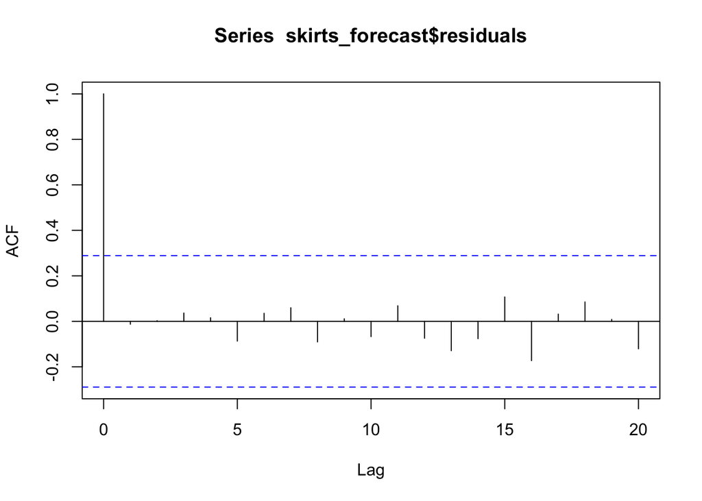

```r
acf(skirts_forecast$residuals, lag.max = 20)
```

```r
Box.test(skirts_forecast$residuals, lag=20, type = "Ljung-Box")
```

```
##
##  Box-Ljung test
##
## data:  skirts_forecast$residuals
## X-squared = 8.5974, df = 20, p-value = 0.9871
```

p-value = 0.9871 相关图显示出在滞后1-20阶中样本自相关值都没有超出显著置信边界，而且Ljung-Box检验的p值为0.99，所以我们推断在滞后1-20阶（lags1-20）中没明显证据说明预测误差是非零自相关的。

*Acf检验说明：残差没有明显的自相关性，Ljung-Box测试显示：所有的P-value>0.05，说明残差为白噪声。*

**2）判断预测误差是否是平均值为零且方差为常数的正态分布** 做预测误差的时间曲线图和直方图（具有正态分布曲线）

**预测误差的均值是否为0**

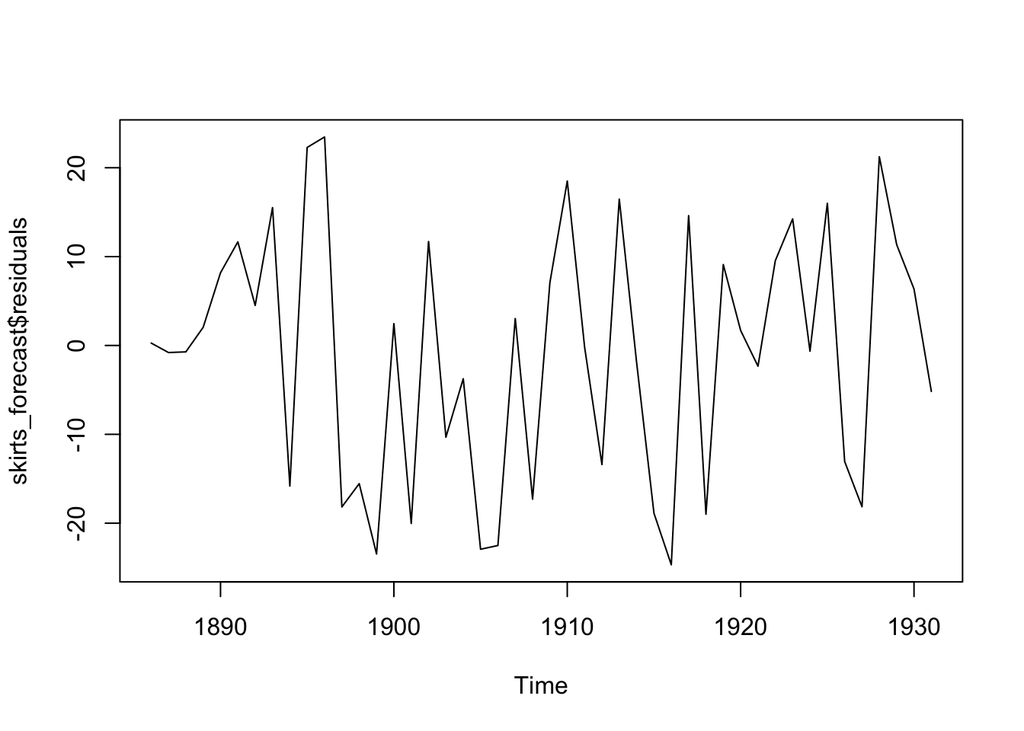

```r
plot.ts(skirts_forecast$residuals)
```

**自定义判断预测误差的方差是正态分布的函数**

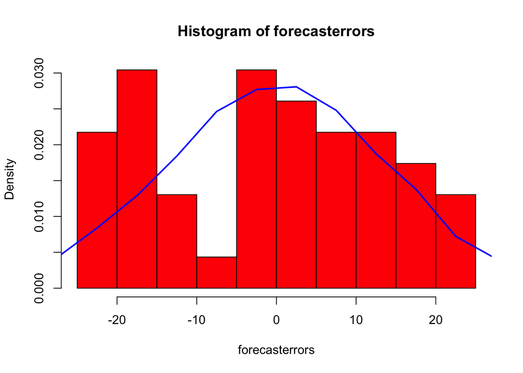

```r
plotForecastErrors <- function(forecasterrors){
  #画预测误差的直方图
  hist(forecasterrors, col="red", freq = F)
  #画方差是预测误差数据的方差，平均值是0的正态分布数据的线
  mysd <- sd(forecasterrors)
  mynorm <- rnorm(10000, mean = 0, sd = mysd)
  myhist <- hist(mynorm, plot = F)
  points(myhist$mids, myhist$density, type="l", col="blue", lwd=2)
}
plotForecastErrors(skirts_forecast$residuals)
```

上图显示出随着时间增加，方差大致为常数（大致不变）（尽管上半部分的时间序列方差看起来稍微高一些）。时间序列的直方图显示预测误大致是正态分布的且平均值接近于0。因此，把预测误差看作平均值为0方差为服从零均值、方差不变的正态分布是合理的。

*既然依次连续的预测误差看起来不是相关，而且服从零均值、方差不变的正态分布，那么对于裙子直径的数据，ARIMA(1,2,5)看起来是可以提供非常合适预测的模型。*